# Análise Bivariada para Variáveis Qualitativas e Discretas

# Introdução

Nesta aula, daremos continuidade ao estudo de visualização de dados com o `ggplot2`, focando na análise bivariada para variáveis qualitativas e discretas. Iremos explorar como comparar duas variáveis utilizando gráficos de barras e gráficos de setores, e como personalizar esses gráficos para destacar diferentes aspectos dos dados.

## Carregando os pacotes necessários

Vamos começar carregando os pacotes necessários para esta aula.

```r
library(tidyverse)
library(RColorBrewer)
```

## Base de Dados

Continuaremos utilizando a base de dados `mtcars`, que foi modificada na aula anterior para incluir variáveis categorizadas. Vamos recarregar e revisar o dataset, tratando também os valores `NA`.

```r
data(mtcars)
tb <- as_tibble(mtcars) %>%
  mutate(cyl_factor = as.factor(cyl),
         hp_group = cut(hp, breaks = c(0, 100, 150, 200, 300),
                        labels = c("Baixa", "Média", "Alta", "Muito Alta")),
         hp_group = fct_explicit_na(hp_group, na_level = "Desconhecido")) # Tratando NA
glimpse(tb)
```

```
Rows: 32
Columns: 13
$ mpg        <dbl> 21.0, 21.0, 22.8, 21.4, 18.7, 18.1, 14.3, 24.4, 22.8, 19.2, 17.8, 16.4, 17.3, 15.2, 10.4, 10.4, 14.7, 32.4, 30.4, 33.9, 21…
$ cyl        <dbl> 6, 6, 4, 6, 8, 6, 8, 4, 4, 6, 6, 8, 8, 8, 8, 8, 8, 4, 4, 4, 4, 8, 8, 8, 8, 4, 4, 4, 8, 6, 8, 4
$ disp       <dbl> 160.0, 160.0, 108.0, 258.0, 360.0, 225.0, 360.0, 146.7, 140.8, 167.6, 167.6, 275.8, 275.8, 275.8, 472.0, 460.0, 440.0, 78.…
$ hp         <dbl> 110, 110, 93, 110, 175, 105, 245, 62, 95, 123, 123, 180, 180, 180, 205, 215, 230, 66, 52, 65, 97, 150, 150, 245, 175, 66, …
$ drat       <dbl> 3.90, 3.90, 3.85, 3.08, 3.15, 2.76, 3.21, 3.69, 3.92, 3.92, 3.92, 3.07, 3.07, 3.07, 2.93, 3.00, 3.23, 4.08, 4.93, 4.22, 3.…
$ wt         <dbl> 2.620, 2.875, 2.320, 3.215, 3.440, 3.460, 3.570, 3.190, 3.150, 3.440, 3.440, 4.070, 3.730, 3.780, 5.250, 5.424, 5.345, 2.2…
$ qsec       <dbl> 16.46, 17.02, 18.61, 19.44, 17.02, 20.22, 15.84, 20.00, 22.90, 18.30, 18.90, 17.40, 17.60, 18.00, 17.98, 17.82, 17.42, 19.…
$ vs         <dbl> 0, 0, 1, 1, 0, 1, 0, 1, 1, 1, 1, 0, 0, 0, 0, 0, 0, 1, 1, 1, 1, 0, 0, 0, 0, 1, 0, 1, 0, 0, 0, 1
$ am         <dbl> 1, 1, 1, 0, 0, 0, 0, 0, 0, 0, 0, 0, 0, 0, 0, 0, 0, 1, 1, 1, 0, 0, 0, 0, 0, 1, 1, 1, 1, 1, 1, 1
$ gear       <dbl> 4, 4, 4, 3, 3, 3, 3, 4, 4, 4, 4, 3, 3, 3, 3, 3, 3, 4, 4, 4, 3, 3, 3, 3, 3, 4, 5, 5, 5, 5, 5, 4
$ carb       <dbl> 4, 4, 1, 1, 2, 1, 4, 2, 2, 4, 4, 3, 3, 3, 4, 4, 4, 1, 2, 1, 1, 2, 2, 4, 2, 1, 2, 2, 4, 6, 8, 2
$ cyl_factor <fct> 6, 6, 4, 6, 8, 6, 8, 4, 4, 6, 6, 8, 8, 8, 8, 8, 8, 4, 4, 4, 4, 8, 8, 8, 8, 4, 4, 4, 8, 6, 8, 4
$ hp_group   <fct> Média, Média, Baixa, Média, Alta, Média, Muito Alta, Baixa, Baixa, Média, Média, Alta, Alta, Alta, Muito Alta, Muito Alta,…
```

## Análise Bivariada para Variáveis Qualitativas e Discretas

### Tipos de Gráficos de Barras

Anteriormente, vimos gráficos de barras para uma única variável. Agora, vamos explorar gráficos de barras que consideram duas variáveis, permitindo uma análise bivariada.

#### Iniciando o Gráfico

Vamos iniciar criando um gráfico básico com as variáveis `cyl_factor` (número de cilindros) e `hp_group` (grupo de potência). Usaremos a estética `fill` para colorir as barras de acordo com o grupo de potência.

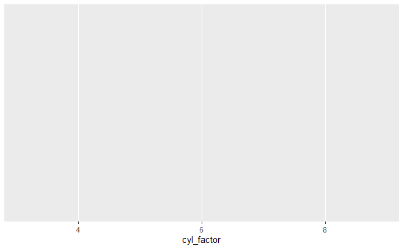

```r
gg <- ggplot(data = tb, mapping = aes(x = cyl_factor, fill = hp_group)) +
  scale_fill_discrete(name = "Grupo de Potência")
gg
```

Esse código inicializa o gráfico `gg` com as duas variáveis mapeadas. O gráfico ainda não tem uma geometria aplicada, então está vazio.

#### Barras Lado a Lado

Vamos criar barras agrupadas (lado a lado) para visualizar a distribuição do número de cilindros por grupo de potência.

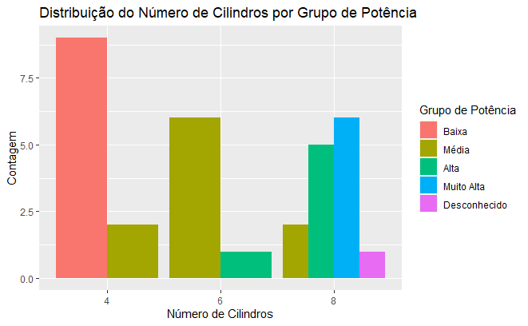

```r
gg + geom_bar(position = "dodge") +
  labs(title = "Distribuição do Número de Cilindros por Grupo de Potência",
       x = "Número de Cilindros", y = "Contagem")
```

Usamos `geom_bar(position = "dodge")` para criar barras lado a lado (agrupadas). Isso permite comparar diretamente as categorias de `hp_group` dentro de cada nível de `cyl_factor`.

#### Barras Empilhadas

Outra opção é empilhar as barras, que facilita a visualização das proporções de cada grupo de potência dentro de cada categoria de cilindros.

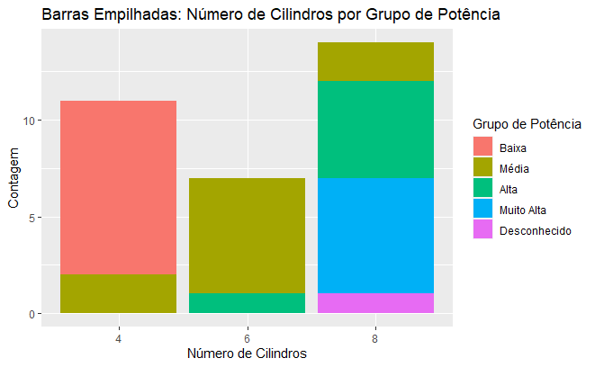

```r
gg + geom_bar(position = "stack") +
  labs(title = "Barras Empilhadas: Número de Cilindros por Grupo de Potência",
       x = "Número de Cilindros", y = "Contagem")
```

Utilizamos `geom_bar(position = "stack")` para empilhar as barras. Esse tipo de gráfico é útil para ver a composição dos grupos de potência em cada categoria de cilindros.

#### Barras Esticadas para Preencher

As barras podem ser normalizadas para ter o mesmo tamanho, o que facilita a comparação relativa entre as categorias.

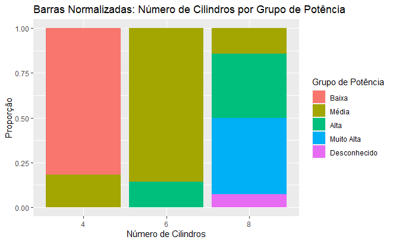

```r
gg + geom_bar(position = "fill") +
  labs(title = "Barras Normalizadas: Número de Cilindros por Grupo de Potência",
       x = "Número de Cilindros", y = "Proporção")
```

Aqui, `geom_bar(position = "fill")` ajusta a altura das barras para que todas tenham a mesma altura, mostrando as proporções relativas de cada categoria.

### Usando Facetas

Podemos dividir o gráfico em facetas para visualizar o cruzamento entre duas variáveis de forma mais detalhada.

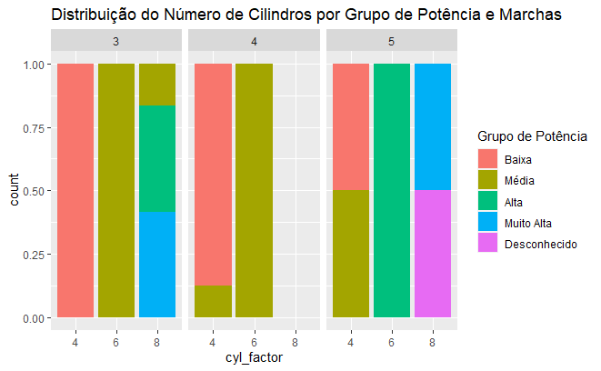

```r
gg +
   geom_bar(position = "fill") +
  facet_wrap(~gear) +
  labs(title = "Distribuição do Número de Cilindros por Grupo de Potência e Marchas")
```

Com `facet_wrap(~gear)`, dividimos o gráfico em múltiplos gráficos menores, cada um representando uma categoria da variável `gear` (número de marchas).

#### Anotações sobre as Barras

Vamos adicionar anotações com a contagem em cada barra para facilitar a interpretação dos gráficos.

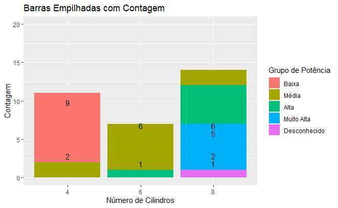

```r
gg + geom_bar(position = "stack") +
  geom_text(aes(label = ..count..), stat = "count", vjust = -0.5) +
  labs(title = "Barras Empilhadas com Contagem", x = "Número de Cilindros", y = "Contagem") +
  ylim(c(NA, 20))
```

Aqui, `geom_text()` adiciona as contagens diretamente sobre as barras, tornando os valores mais fáceis de visualizar.

### Gráficos de Setores (Pizza)

Agora, vamos explorar gráficos de setores, começando com a conversão de um gráfico de barras para um gráfico de pizza.

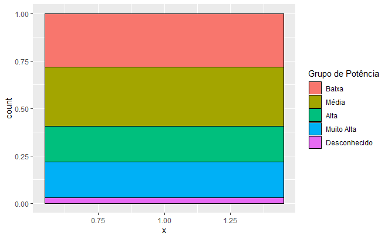

```r
gg <- ggplot(data = tb, mapping = aes(x = 1, fill = hp_group)) +
  scale_fill_discrete(name = "Grupo de Potência")
gg + geom_bar(color = "black", position = "fill")
```

Esse gráfico de barras será convertido para um gráfico de setores ao mudar o sistema de coordenadas.

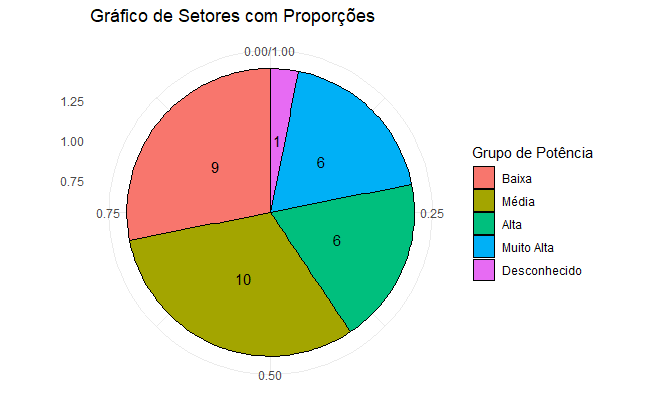

```r
gg + geom_bar(color = "black", position = "fill") +
  geom_text(aes(y = ..count../sum(..count..), label = ..count..),
            stat = "count", position = position_stack(vjust = 0.5)) +
  coord_polar(theta = "y") +
  labs(title = "Gráfico de Setores com Proporções", x = NULL, y = NULL) +
  theme_minimal()
```

Aqui, `coord_polar(theta = "y")` converte o gráfico de barras em um gráfico de setores. As anotações no gráfico mostram a contagem total dentro de cada setor.

### Modificação de Escalas de Cores

Podemos personalizar as cores manualmente ou utilizando paletas pré-definidas, como as disponíveis no pacote `RColorBrewer`.

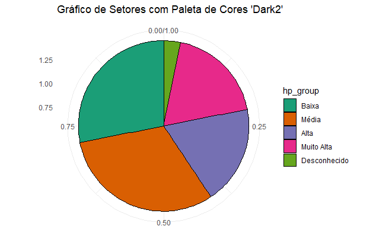

```r
gg + geom_bar(color = "black", position = "fill") +
  coord_polar(theta = "y") +
  scale_fill_brewer(palette = "Dark2") +
  labs(title = "Gráfico de Setores com Paleta de Cores 'Dark2'", x = NULL, y = NULL) +
  theme_minimal()
```

Aqui, `scale_fill_brewer(palette = "Dark2")` aplica a paleta de cores “Dark2” ao gráfico de setores.